# Kaggle Competition : Forest Cover Type

```python
import pandas as pd
import numpy as np
from sklearn import linear_model as lm
from sklearn.neighbors import KNeighborsClassifier
from sklearn.ensemble import RandomForestClassifier
from sklearn.ensemble import ExtraTreesClassifier
from sklearn.ensemble import GradientBoostingClassifier
from sklearn import tree
from sklearn import metrics
import matplotlib.pyplot as plt
import pandas.plotting as pdplt
import seaborn as sns
import warnings
```

```python
# Set some options:
warnings.filterwarnings('ignore')
pd.set_option('display.max_rows', 15)
# np.random.seed(2)
%matplotlib inline
%precision 4
```

```
'%.4f'
```

# Load Data :

```python
df_test = pd.read_csv("test-set.csv", sep=",", index_col="Id")
df_train = pd.read_csv("train-set.csv", sep=",", index_col="Id")
```

```python
df_train.head()
```

| Id | Elevation | Aspect | Slope | Horizontal_Distance_To_Hydrology | Vertical_Distance_To_Hydrology | Horizontal_Distance_To_Roadways | Hillshade_9am | Hillshade_Noon | Hillshade_3pm | Horizontal_Distance_To_Fire_Points | ... | Soil_Type32 | Soil_Type33 | Soil_Type34 | Soil_Type35 | Soil_Type36 | Soil_Type37 | Soil_Type38 | Soil_Type39 | Soil_Type40 | Cover_Type |
| --- | --- | --- | --- | --- | --- | --- | --- | --- | --- | --- | --- | --- | --- | --- | --- | --- | --- | --- | --- | --- | --- |
| 1 | 2611 | 326 | 20 | 120 | 27 | 1597 | 168 | 214 | 184 | 2913 | ... | 0 | 0 | 0 | 0 | 0 | 0 | 0 | 0 | 0 | 6 |
| 2 | 2772 | 324 | 17 | 42 | 7 | 1814 | 175 | 220 | 183 | 2879 | ... | 0 | 0 | 0 | 0 | 0 | 0 | 0 | 0 | 0 | 2 |
| 3 | 2764 | 4 | 14 | 480 | -21 | 700 | 201 | 212 | 148 | 700 | ... | 0 | 0 | 0 | 0 | 0 | 0 | 0 | 0 | 0 | 2 |
| 4 | 3032 | 342 | 9 | 60 | 8 | 4050 | 202 | 227 | 164 | 2376 | ... | 0 | 0 | 0 | 0 | 0 | 0 | 0 | 0 | 0 | 2 |
| 5 | 2488 | 23 | 11 | 117 | 21 | 1117 | 209 | 218 | 151 | 1136 | ... | 0 | 0 | 0 | 0 | 0 | 0 | 0 | 0 | 0 | 2 |

5 rows × 55 columns

# First Approach : testing different classifier as is :

**Here we are in a problem of classification. We want to classify 7 type of trees' Cover. That means, classifier algorithm are recommanded. Here I wanted to try different type classifier, discover how they work, to see how they react, how close (or far) we are from the target. It's more for my personal understanding in a learning process than anything else. Also, the result we catch here will be useful as sample score to compare later.**

First we need to split the data set into X train/test and Y test/test :

```python
# Split the Train_set into X and Y
X = df_train.iloc[:,:-1]
Y = df_train.loc[:,'Cover_Type']
```

```python
# Split of the Train_set into 2 subsets train and test to do more try without submiting to kaggle
from sklearn import datasets, linear_model
from sklearn.model_selection import train_test_split
X_train, X_test, Y_train, Y_test = train_test_split(X, Y, test_size=0.2, random_state = 2)

print ("X_train shape : " + str(X_train.shape))
print ("Y_train shape : " + str(Y_train.shape))
print ("X_test shape : " + str(X_test.shape))
print ("Y_test shape : " + str(Y_test.shape))
```

```
X_train shape : (422976, 54)
Y_train shape : (422976,)
X_test shape : (105744, 54)
Y_test shape : (105744,)
```

### 1-Logistic Regression :

```python
# %%timeit -n1 -r1
reg_lr = lm.LogisticRegression(random_state=2, n_jobs=-1)
reg_lr = lm.LogisticRegression().fit(X_train.values,Y_train.values)
print("score logistic regression = %.4f" %reg_lr.score(X_test.values,Y_test.values))
```

```
score logistic regression = 0.7044
```

### 2-Nearest Neighbors :

```python
# %%timeit -n1 -r1
neigh = KNeighborsClassifier(n_jobs=-1)
neigh = neigh.fit(X_train.values, Y_train.values)
neigh_score_0 = neigh.score(X_test.values,Y_test.values)
print("Score KNN = %.4f" %neigh_score_0)
```

```
Score KNN = 0.9208
```

### 3-Random Forest :

```python
# %%timeit -n1 -r1
rf_clf = RandomForestClassifier(random_state=2, n_jobs=-1)
rf_clf = rf_clf.fit(X_train.values, Y_train.values)
rf_clf_score_0 = rf_clf.score(X_test.values, Y_test.values.ravel())
print ("Random Forest score = %.4f" %rf_clf_score_0)
```

```
Random Forest score = 0.9205
```

### 4-Decision Tree Classifier :

```python
# %%timeit -n1 -r1
dt_clf = tree.DecisionTreeClassifier(random_state=2)
dt_clf = dt_clf.fit(X_train.values, Y_train.values.ravel())
print("Decision Tree score = %.4f" %dt_clf.score(X_test.values, Y_test.values.ravel()))
```

```
Decision Tree score = 0.9021
```

### 5-Extra Trees Classifier (Ensemble library)

```python
# %%timeit -n1 -r1
et_clf = ExtraTreesClassifier(random_state=2, n_jobs=-1)
et_clf = et_clf.fit(X_train.values, Y_train.values)
et_clf_score_0 = et_clf.score(X_test.values, Y_test.values)
print("Extra Tree score = %.4f" %et_clf_score_0)
```

```
Extra Tree score = 0.9224
```

We can see that without any tuning nor cleaning we already have pretty good results !  
Best results are optained with Random Forest, Nearest Neighbors and Extra Trees. So to simplify the exercise we'll continue with those 3 classifier only  
(I tried with the other classifier too, but I didn't get better results so I won't show it to streamline the reading)

# Cleaning & Data Vizualization

```python
df_train.describe()
```

|  | Elevation | Aspect | Slope | Horizontal_Distance_To_Hydrology | Vertical_Distance_To_Hydrology | Horizontal_Distance_To_Roadways | Hillshade_9am | Hillshade_Noon | Hillshade_3pm | Horizontal_Distance_To_Fire_Points | ... | Soil_Type32 | Soil_Type33 | Soil_Type34 | Soil_Type35 | Soil_Type36 | Soil_Type37 | Soil_Type38 | Soil_Type39 | Soil_Type40 | Cover_Type |
| --- | --- | --- | --- | --- | --- | --- | --- | --- | --- | --- | --- | --- | --- | --- | --- | --- | --- | --- | --- | --- | --- |
| count | 528720.000000 | 528720.000000 | 528720.000000 | 528720.000000 | 528720.000000 | 528720.000000 | 528720.000000 | 528720.000000 | 528720.000000 | 528720.000000 | ... | 528720.000000 | 528720.000000 | 528720.000000 | 528720.000000 | 528720.000000 | 528720.000000 | 528720.000000 | 528720.000000 | 528720.000000 | 528720.000000 |
| mean | 2959.800552 | 155.629891 | 14.095043 | 269.731845 | 46.474718 | 2352.595141 | 212.153062 | 223.343970 | 142.555615 | 1979.363977 | ... | 0.090365 | 0.077678 | 0.002792 | 0.003276 | 0.000202 | 0.000471 | 0.026916 | 0.023646 | 0.015118 | 2.052294 |
| std | 280.351766 | 112.095470 | 7.501853 | 213.069124 | 58.433933 | 1563.557679 | 26.793767 | 19.813479 | 38.336178 | 1325.877589 | ... | 0.286705 | 0.267665 | 0.052762 | 0.057141 | 0.014224 | 0.021696 | 0.161838 | 0.151943 | 0.122021 | 1.396863 |
| min | 1759.000000 | -72.000000 | -3.000000 | -144.000000 | -182.000000 | -805.000000 | -2.000000 | 0.000000 | -17.000000 | -704.000000 | ... | 0.000000 | 0.000000 | 0.000000 | 0.000000 | 0.000000 | 0.000000 | 0.000000 | 0.000000 | 0.000000 | 1.000000 |
| 25% | 2809.000000 | 58.000000 | 9.000000 | 108.000000 | 7.000000 | 1106.000000 | 198.000000 | 213.000000 | 119.000000 | 1024.000000 | ... | 0.000000 | 0.000000 | 0.000000 | 0.000000 | 0.000000 | 0.000000 | 0.000000 | 0.000000 | 0.000000 | 1.000000 |
| 50% | 2996.000000 | 127.000000 | 13.000000 | 223.000000 | 30.000000 | 2001.000000 | 218.000000 | 226.000000 | 143.000000 | 1710.000000 | ... | 0.000000 | 0.000000 | 0.000000 | 0.000000 | 0.000000 | 0.000000 | 0.000000 | 0.000000 | 0.000000 | 2.000000 |
| 75% | 3163.000000 | 260.000000 | 18.000000 | 387.000000 | 69.000000 | 3333.000000 | 231.000000 | 237.000000 | 168.000000 | 2550.000000 | ... | 0.000000 | 0.000000 | 0.000000 | 0.000000 | 0.000000 | 0.000000 | 0.000000 | 0.000000 | 0.000000 | 2.000000 |
| max | 3957.000000 | 440.000000 | 65.000000 | 1397.000000 | 601.000000 | 7577.000000 | 268.000000 | 266.000000 | 259.000000 | 7548.000000 | ... | 1.000000 | 1.000000 | 1.000000 | 1.000000 | 1.000000 | 1.000000 | 1.000000 | 1.000000 | 1.000000 | 7.000000 |

8 rows × 55 columns

```python
# Data Cleaning : Check if any Null or NaN.
print("There is Null : "+str(df_train.isna().values.any()))
print("There is NaN : "+str(df_train.isnull().values.any()))
```

```
There is Null : False
There is NaN : False
```

As we can see there is no Null nor NaN. However we can see some negative value on distance and 0 values at Hillshade.  
Lets plot the matrix to better understand the data :

## 1. Let's have a look at the target Cover Type first:

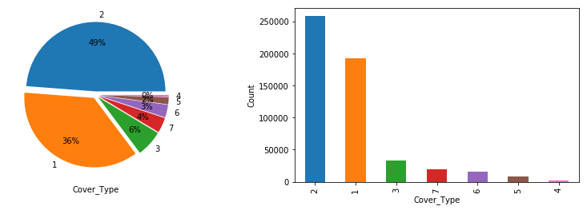

```python
fig = plt.figure(figsize=(14,4))
plt.subplot(121).set_xlabel('Cover_Type')
plt.pie(Y.value_counts(), labels=Y.value_counts().index, autopct='%1.0f%%', pctdistance=0.7
        ,labeldistance=1.1,explode=[.05,.05,.05,.05,.05,.05,.05])
plt.subplot(122).set_xlabel('Cover_Type')
plt.subplot(122).set_ylabel('Count')
Y.value_counts().plot.bar()
```

**We have a majority of Cover Type of kind 1 and 2 that represent more than 85% of the data set.**

## 2. Let's have a look at the features now :

We can see that the features matrix can be separated in 3 parts :

- Columns 1 to 10 are contineous values (Elevation, Slope etc.)
- Columns 10 to 14 are sparse and it represent different kind of Wilderness
- Columns 14 to End are sparse and it represent different kind of Soil type

So we gonna look at each one of these part :

### Features 1 to 10 (continuous) :

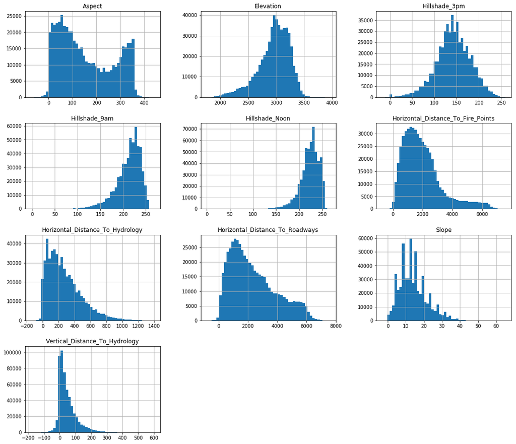

```python
X.iloc[:,:10].hist(bins=50,figsize=(18,16))
plt.show()
```

**Here we can see some aberrant values in the features. For example, Hill Shade are not supposed to be <=0. Also Horizontal distance should be only positive. We'll remove those aberrant values later and see if it improves the model.**

### Features 10 to End (Sparse) :

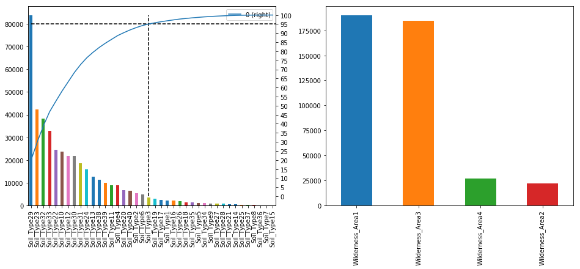

```python
plt.subplot(121)
perc= pd.DataFrame((X_train.iloc[:,14:].sum().sort_values(ascending=False)/X_train.iloc[:,14:].sum().sum())*100)
perc.cumsum()
ax1 = X_train.iloc[:,14:].sum().sort_values(ascending=False).plot.bar(figsize=(16,6))
perc.cumsum().plot(secondary_y=True,ax=ax1, rot=90)
plt.hlines(y=95,xmin=0,xmax=100,linestyles='dashed')
plt.vlines(x=19,ymax=100,ymin=0,linestyles='dashed')
plt.yticks(ticks=np.arange(0,101,5))
plt.subplot(122)
ax2=X_train.iloc[:,10:14].sum().sort_values(ascending=False).plot.bar()
plt.show()
```

## Compression of Sparse Matrix to improve computation time

**As the computation takes time, there is an other thing that I tried to do as we have sparse matrix :**  
I wanted to make a compression of the data to accelarate the computation time. Unfortunately, this method doesn't work with classifier trees nor Random Forest. However I'll show the process as part of my work :

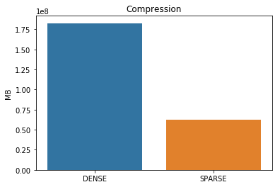

```python
from scipy.sparse import csr_matrix
X_train_sparse = csr_matrix(X_train)
dense_size = np.array(X_train).nbytes
sparse_size = (X_train_sparse.data.nbytes + X_train_sparse.indptr.nbytes + X_train_sparse.indices.nbytes)

sns.barplot(['DENSE', 'SPARSE'], [dense_size, sparse_size])
plt.ylabel('MB')
plt.title('Compression')
```

## Removing Aberrant values :

**As we saw above, there are some aberant values that we want to remove :**

```python
# Removin aberrant values :
df_train_2 = df_train
df_train_2 = df_train_2[df_train_2.Hillshade_3pm>0]
df_train_2 = df_train_2[df_train_2.Hillshade_Noon>0]
df_train_2 = df_train_2[df_train_2.Hillshade_9am>0]
df_train_2 = df_train_2[df_train_2.Horizontal_Distance_To_Fire_Points>0]
df_train_2 = df_train_2[df_train_2.Horizontal_Distance_To_Hydrology>0]
df_train_2 = df_train_2[df_train_2.Horizontal_Distance_To_Roadways>0]
print("row deleted : %d" %(df_train.shape[0]-df_train_2.shape[0]))
print("%% deleted : %.2f%%" %((df_train.shape[0]-df_train_2.shape[0])*100/528520))
```

```
row deleted : 23802
% deleted : 4.50%
```

**So we deleted 23.802 raws. It's a lot but in regard of the whole data set it's not so much as it's only 4.5%. And as we'll see later, it slightly improve our model.**

```python
# Split the Train_set into X and Y

X = df_train_2.iloc[:,:-1]
Y = df_train_2.loc[:,'Cover_Type']
```

```python
# Split of the Train_set into 2 subsets train and test to do more try without submiting to kaggle
from sklearn import datasets, linear_model
from sklearn.model_selection import train_test_split
X_train, X_test, Y_train, Y_test = train_test_split(X, Y, test_size=0.2, random_state = 2)

print ("X_train shape : " + str(X_train.shape))
print ("Y_train shape : " + str(Y_train.shape))
print ("X_test shape : " + str(X_test.shape))
print ("Y_test shape : " + str(Y_test.shape))
```

```
X_train shape : (403934, 54)
Y_train shape : (403934,)
X_test shape : (100984, 54)
Y_test shape : (100984,)
```

### Nearest Neighbors after cleaning

```python
# %%timeit -n1 -r1
neigh = KNeighborsClassifier(n_jobs=-1)
neigh = neigh.fit(X_train.values, Y_train.values)
neigh_score_cleaned = neigh.score(X_test.values,Y_test.values)
print("Score KNN = %.4f" %neigh_score_cleaned)
```

```
Score KNN = 0.9237
```

### Random Forest after cleaning :

```python
# %%timeit -n1 -r1
rf_clf = RandomForestClassifier(random_state=2, n_jobs=-1)
rf_clf = rf_clf.fit(X_train.values, Y_train.values)
rf_clf_score_cleaned = rf_clf.score(X_test.values, Y_test.values.ravel())
print ("Random Forest score = %.4f" %rf_clf_score_cleaned)
```

```
Random Forest score = 0.9238
```

### Extra Trees Classifier after cleaning :

```python
# %%timeit -n1 -r1
et_clf = ExtraTreesClassifier(random_state=2, n_jobs=-1)
et_clf = et_clf.fit(X_train.values, Y_train.values)
et_clf_score_cleaned = et_clf.score(X_test.values, Y_test.values)
print("Extra Tree score = %.4f" %et_clf_score_cleaned)
```

```
Extra Tree score = 0.9254
```

**As we can see, we improved the score with some cleaning for both of the classifiers.**

# Feature Reduction :

## 1. Reduction with PCA

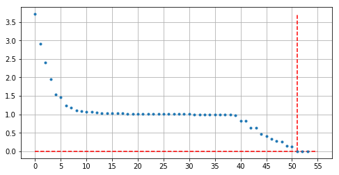

```python
from matplotlib.pyplot import figure
from sklearn.decomposition import PCA
from sklearn import preprocessing

# Normalization :
scaler = preprocessing.StandardScaler().fit(X_train)
X_train_normalized = pd.DataFrame(scaler.transform(X_train))
scaler2 = preprocessing.StandardScaler().fit(X_test)
X_test_normalized = pd.DataFrame(scaler2.transform(X_test))

# Fit le model à la matrice X_train :
pca = PCA(svd_solver='auto')
pca.fit(X_train_normalized)

# # Valeurs propres de la matrice cov(X_train) triées par ordre décroissant :
v_propres = pd.DataFrame(pca.explained_variance_)

figure(figsize=(8,4))
plt.grid()
plt.xticks(np.arange(0, 60, 5))
# plt.yscale(value="log")
plt.plot(v_propres.abs().values,'.')
plt.vlines(x=51, ymin=0,ymax=v_propres.max(), colors='r',linestyles='dashed')
plt.hlines(y=0, xmin=0,xmax=55, colors='r',linestyles='dashed')
```

```python
# Transform the X_train keeping the 50 vectors different of zero:
pca = PCA(n_components=51,svd_solver='auto')
X_train_pca = pca.fit_transform(X_train_normalized)
X_train_pca = pd.DataFrame(X_train_pca)
```

### Nearest Neighbors with PCA

```python
# %%timeit -n1 -r1
neigh_pca = KNeighborsClassifier(n_jobs=-1)
neigh_pca = neigh_pca.fit(X_train_pca.values, Y_train.values)
neigh_score_pca = neigh_pca.score(pca.transform(X_test_normalized.values),Y_test.values)
print("Score KNN PCA = %.4f" %neigh_score_pca)
```

```
Score KNN PCA = 0.9242
```

### Random Forest with PCA

```python
# %%timeit -n1 -r1
rf_clf_pca=RandomForestClassifier(n_jobs=-1, random_state=0)
rf_clf_pca=rf_clf_pca.fit(X_train_pca.values, Y_train.values)
rf_clf_score_pca = rf_clf_pca.score(pca.transform(X_test_normalized.values), Y_test.values)
print ("Random Forest PCA score = %.4f" %rf_clf_score_pca)
```

```
Random Forest PCA score = 0.8953
```

### Extra Trees Classifier with PCA

```python
et_clf_pca = ExtraTreesClassifier(random_state=2, n_jobs=-1)
et_clf_pca = et_clf_pca.fit(X_train_pca.values, Y_train.values)
et_clf_score_pca = et_clf_pca.score(pca.transform(X_test_normalized.values), Y_test.values)
print("Extra Tree PCA score = %.4f" %et_clf_score_pca)
```

```
Extra Tree PCA score = 0.9045
```

**As we can see here, the PCA improves the model for KNN but doesn't for Random Forest or Extra Trees. So we won't keep this method and try an other one with the "feature_importance" from the trees and random forest classifier.**

## 2. Analizing Impactant Features :

### From Random Forest :

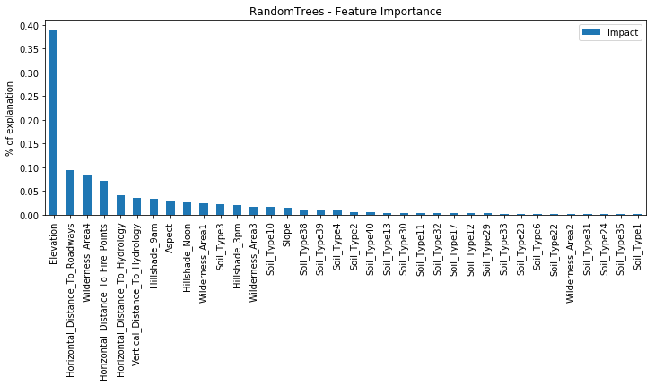

```python
# Sort the features :
importance = pd.DataFrame(rf_clf.feature_importances_)
ind = importance.sort_values(by=0, ascending=False).index
sorted_importance = importance.sort_values(ascending=False,by=0)
features_sorted = pd.DataFrame(index=X_train.columns[ind])
features_sorted['Impact'] = sorted_importance.values

# Treshold >0.1% impact :
best_features = features_sorted[features_sorted.Impact>0.001]

X_train_best = X_train[best_features.index]
X_test_best = X_test[best_features.index]

best_features.plot(kind='bar', figsize=(12,4))
plt.ylabel(ylabel='% of explanation')
plt.title('RandomTrees - Feature Importance')
plt.show()
```

### From Extra Tress :

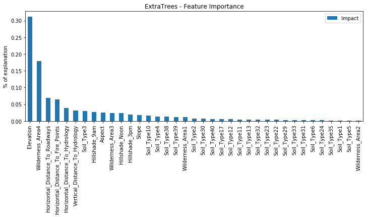

```python
# Sort the features :
importance_et = pd.DataFrame(et_clf.feature_importances_)
ind = importance_et.sort_values(by=0, ascending=False).index
sorted_importance_et = importance_et.sort_values(ascending=False,by=0)
features_sorted_et = pd.DataFrame(index=X_train.columns[ind])
features_sorted_et['Impact'] = sorted_importance_et.values

# Treshold impact >0.1% :
best_features_et = features_sorted_et[features_sorted_et.Impact>0.001]

X_train_best_et = X_train[best_features_et.index]
X_test_best_et = X_test[best_features_et.index]

best_features_et.plot(kind='bar', figsize=(12,4))
plt.ylabel(ylabel='% of explanation')
plt.title('ExtraTrees - Feature Importance')
plt.show()
```

### Nearest Neighbors with Impact Feature Selection

```python
# %%timeit -n1 -r1
neigh_impact = KNeighborsClassifier(n_jobs=-1)
neigh_impact = neigh_impact.fit(X_train_best_et.values, Y_train.values)
neigh_score_impact = neigh_impact.score(X_test_best_et.values,Y_test.values)
print("Score KNN = %.4f" %neigh_score_impact)
```

```
Score KNN = 0.9237
```

### Random Forest with Impactant feature selection :

```python
rf_clf_impact = RandomForestClassifier(n_jobs=-1, random_state=2)
rf_clf_impact = rf_clf_impact.fit(X_train_best.values, Y_train.values)
rf_clf_score_impact = rf_clf_impact.score(X_test_best.values, Y_test.values)
print ("Random Forest score = %.4f" %rf_clf_score_impact)
```

```
Random Forest score = 0.9250
```

### Extra Tree with Impactant feature selection :

```python
et_clf_impact = ExtraTreesClassifier(random_state=2, n_jobs=-1)
et_clf_impact = et_clf_impact.fit(X_train_best_et.values, Y_train.values)
et_clf_score_impact = et_clf_impact.score(X_test_best_et.values, Y_test.values)
print("Extra Tree score = %.4f" %et_clf_score_impact)
```

```
Extra Tree score = 0.9249
```

## Radar Viz & Scatter Matrix with top 5 important features :

**Once we have reduces the features and classified them relatively to their importance we would like to prompt some relations between each other to better understand the data and try to do a better analysis. We'll take only the 5 most impactant features :**

### Scatter Matrix :

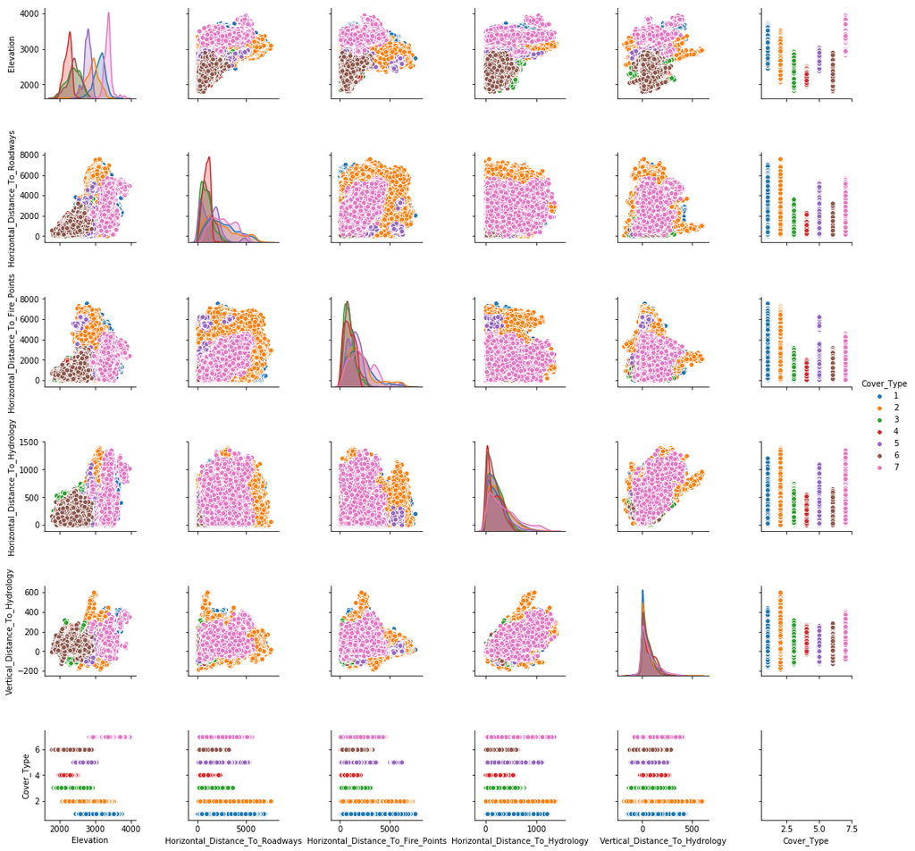

```python
sns.pairplot(X_train.loc[:,best_features[:5].index].join(Y), hue='Cover_Type')
```

**Regarding the graphs it's hard to get to a relevant conclusion. However we can see by the repartition of the data that a tree classifier should suit best for this classification**

### RadarViz

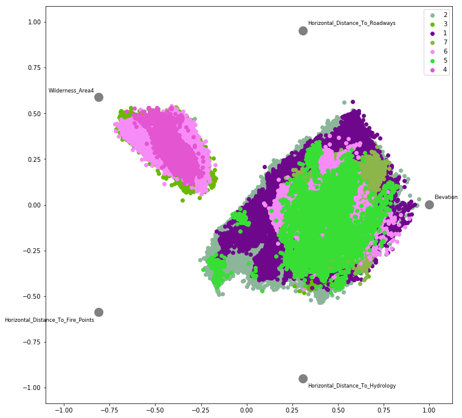

```python
from pandas.plotting import radviz
plt.figure(figsize=(12,12))
radviz(X_train.loc[:,best_features[:5].index].join(Y), 'Cover_Type')
```

**Here we can clearly see that the Cover Type 3, 4 and 6 are really impacted by the Wilderness_Area_4. However this I don't know I can use this information to optimize the classifier.**

# Tests Summary :

```python
# Extra Trees :
data =[[rf_clf_score_0,rf_clf_score_cleaned,rf_clf_score_pca,rf_clf_score_impact],
       [et_clf_score_0,et_clf_score_cleaned,et_clf_score_pca,et_clf_score_impact],
       [neigh_score_0,neigh_score_cleaned,neigh_score_pca,neigh_score_impact]]

Summary = pd.DataFrame(index=['RandomForest','ExtraTrees','KNN'], columns=['Initial', 'Cleaned', 'PCA', 'Importance'],
                       data=data)
Summary
```

|  | Initial | Cleaned | PCA | Importance |
| --- | --- | --- | --- | --- |
| RandomForest | 0.920516 | 0.923849 | 0.895261 | 0.924958 |
| ExtraTrees | 0.922445 | 0.925404 | 0.904510 | 0.924909 |
| KNN | 0.920809 | 0.923671 | 0.924206 | 0.923671 |

**Finally, I found that the best model was met for Extra Trees with "cleaned" data. So I will now try to tune the model of the Extra Trees classifier only on cleaned data and nothing else.**

# Tuning & Cross Validation

**To improve the model and find the best hyper parameters, I wanted to make a grid search + cross validation on the Random Forest and Extra Trees. However, the algorithm didn't converge in reasonable time (>6H running). Below is the code for the GridSearch Cross Validation that I used :**

```python
"""
from sklearn.model_selection import GridSearchCV
param_grid = dict(n_estimators=[200,400,600,800,1000],criterion=['entropy','gini']
                  ,bootstrap=[True],max_features=['auto','None']
                  , oob_score=[True, False], n_jobs=[-1], random_state=[2])
print(param_grid)
"""
```

```python
"""
et_clf=ExtraTreesClassifier()
grid = GridSearchCV(rf_clf, param_grid=param_grid, cv=5)
grid.fit(X_train.values, Y_train.values)

bestparam= pd.DataFrame(grid.best_params_)

print(grid.best_score_)
print(grid.best_params_)
"""
```

**As the gridSearchCV didn't converge, I tryied different parameters by myself and found some good, better but not best, hyper parameters for the two algorithm.**

# Improving the model with Hyper Parameters Selection

## Extra Trees :

**After many try of tuning, I found the best hyper parameters I could with the imparted time I had. That's with this classifier and parameters that I get my best result on Kaggle with a 0.95576 score.**

```python
# %%timeit -n1 -r1
et_clf = ExtraTreesClassifier(n_estimators=500, bootstrap=False, criterion='entropy'
                              , max_features=54, oob_score=False, n_jobs=-1, random_state=2, class_weight='balanced')
et_clf = et_clf.fit(X.values, Y.values)
et_clf_score_final = et_clf.score(X_test.values, Y_test.values)
print("Extra Tree score = %.4f" %et_clf_score_final)
```

```python
# Export the result to .CSV
tmp = df_test
tmp['Cover_Type']=et_clf.predict(df_test.values)
test_pred = tmp['Cover_Type']
test_pred.to_csv('Extra_tree.csv', header=True)
```

**(Here I didn't run the function for the report as it takes arround 1h to run)**